# Simulation Exercise and Basic Data Analysis

Jean-Paul Courneya

8/6/2017

```r
library(knitr)
opts_chunk$set(tidy.opts=list(width.cutoff=60),tidy=TRUE)
```

# This class project consists of two parts:

#### 1. A simulation exercise.

#### 2. Basic inferential data analysis.

First you will set a working directory and load dependencies

```r
setwd()
library(knitr)
library(ggplot2)
```

# Part 1: Simulation Exercise

## Investigating the distribution of averages of 40 exponentials.

### Illustrate via simulation and associated explanatory text the properties of the distribution of the mean of 40 exponentials.

Use set.seed so that the simulation can be repeated. Setting the seed provides the same starting value to the random number generating function.

```r
set.seed(15)
```

set some constants

```r
lambda <- 0.2
sampleSize <- 40
simulations <- 1000
```

##### Start by taking a look at the distribution of a sample of 40 random exponentials

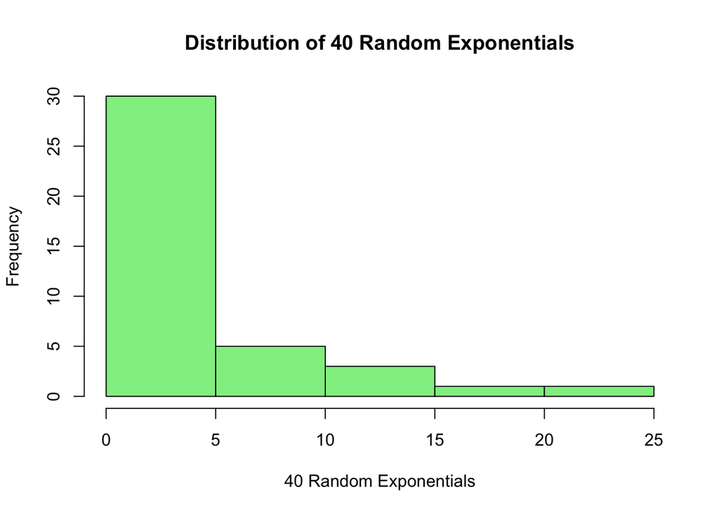

```r
SimDist <- rexp(sampleSize, 0.2)
hist(SimDist, xlab = "40 Random Exponentials", ylab = "Frequency",
    main = "Distribution of 40 Random Exponentials", col = "lightgreen")
```

### Clearly we see that 40 random exponentials chosen look exponentially distributed.

## Calculate the Sample vs Theoretical Mean

##### Next we will evaluate the mean of the sample data set from above.

```r
Sample.Mean <- mean(SimDist)
cat("Sample Mean: ", Sample.Mean)
```

```
## Sample Mean:  4.506131
```

##### The theoretical mean for an eponential distribution as stated in the instructions is 1/lambda

```r
Theoretical.Mean <- 1/lambda
cat("Theoretical Mean: ", Theoretical.Mean)
```

```
## Theoretical Mean:  5
```

The sample mean approximates the theoretical mean.

## Calculate the Sample vs Theoretical Variance

```r
Sample.Variance <- var(SimDist)
cat("Sample Variance: ", Sample.Variance)
```

```
## Sample Variance:  21.66123
```

```r
Theoretical.Variance <- (1/lambda)^2/sampleSize
cat("Theoretical Variance: ", Theoretical.Variance)
```

```
## Theoretical Variance:  0.625
```

There is a big difference between the sample variance and theoretical variance.

##### Now that we have seen the mean and variance of 40 random exponentials and compared it to the theoretical mean and variance. Next we will look at the distribution of the mean of 40 exponentials run 1000 times.

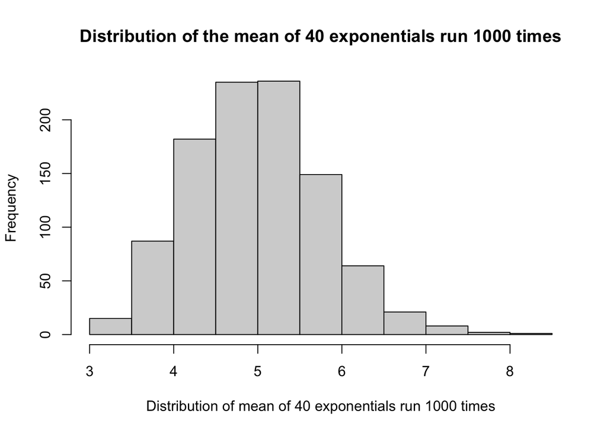

```r
Simulation <- replicate(1000, mean(rexp(40, 0.2)))
hist(Simulation, xlab = "Distribution of mean of 40 exponentials run 1000 times",
    ylab = "Frequency", main = "Distribution of the mean of 40 exponentials run 1000 times",
    col = "lightgrey")
```

##### The data show a distribution around a central point of 5.

##### Next we will evaluate the mean of the replicated sample data set.

```r
mean(replicate(1000, rexp(40, 0.2)))
```

```
## [1] 4.976328
```

### This distribution looks far more Gaussian than the original exponential distribution!